# Task 2 -

Logan Ossentjuk

```r
knitr::opts_chunk$set(echo = TRUE, message = FALSE, warning = FALSE)
library(tidyverse)
library(janitor)
library(here)
library(NbClust)
library(ggdendro)
```

**Use hierarchical clustering by complete linkage to create a dendrogram showing multivariate clustering for water chemistry by site.** To perform hierarchical clustering by site, you’ll want to make a data frame that has a single summary row per site (e.g. based on means from all observations at that site), then *calculate the Euclidean distance before performing complete linkage agglomerative hierarchical clustering*.

Link to the data: https://drive.google.com/file/d/16rYLBi-CgvjcWhOsX1SLdD9HHUMP9m2l/view?usp=sharing

**DATA & METADATA SOURCE:** SBC LTER: Stream chemistry in the Santa Barbara Coastal drainage area, ongoing since 2000 Creators: Santa Barbara Coastal LTER, & Melack, John M Citation: Santa Barbara Coastal LTER and J. Melack. 2019. SBC LTER: Land: Stream chemistry in the Santa Barbara Coastal drainage area, ongoing since 2000 ver 16. Environmental Data Initiative. https://doi.org/10.6073/pasta/67a558a24ceed9a0a5bf5e46ab841174.

**- Create a finalized HTML (knitted from .Rmd) that includes:** - *A useful descriptive introductory summary (3 - 4 sentences)* that helps the audience understand the data (include a citation as necessary) and what you’ll be exploring - *All of your organized and well-annotated code (with warnings/messages suppressed)* you wrote to wrangle data then create the dendrogram, and to create a professional looking dendrogram ?that appears (with a caption) in your knitted HTML.

```
- Optional: rerun the dendrogram using a single linkage method, and include a tanglegram (inaddition to your pro-quality dendrogram) to show how the different linkage changes the  clustering.

- *A brief summary* (nicely formatted and professionally written bulletpoints are fine) highlighting some major takeaways from your hierarchical clustering analysis that can be gleaned from the dendrogram(s).
```

# Overview:

This brief report examines the water chemistry of streams from six sites at the Santa Barbara Coastal Long Term Ecological Research (LTER) beginning in 2000. Complete linkage agglomerative hierarchical clustering is utilized in creating a dendrogram that illustrates the multivariate clustering based on measurement site. First, the mean value of each chemical measurement is acquired by site. Second, the aforementioned clustering analysis is performed to illuminate relationships among variables. Lastly, conclusions are drawn based on the relationships shown in the dendgrogram below.

**Data Citation:** Santa Barbara Coastal LTER and J. Melack. 2019. SBC LTER: Land: Stream chemistry in the Santa Barbara Coastal drainage area, ongoing since 2000 ver 16. Environmental Data Initiative. https://doi.org/10.6073/pasta/67a558a24ceed9a0a5bf5e46ab841174.

```r
#Data Wrangling

stream_chem <- read_csv(here("data", "sbc_lter_registered_stream_chemistry.csv")) %>%
  clean_names() %>%
  na_if(-999.0) %>%
  drop_na() %>%
  group_by(site_code)

stream_chem_sum <- stream_chem %>%
  summarize_all(mean, na.rm = TRUE)

stream_chem_scale <- stream_chem_sum %>%
  select (-timestamp_local, -site_code) %>%
  scale()

  rownames(stream_chem_scale) <- stream_chem_sum$site_code #converts site_code to row names
```

```r
#Calculations - agglomerative hierarchical clustering analysis

#Calculate Euclidean distance before performing complete linkage agglomerative hierarchical clustering
euc_dist <- dist(stream_chem_scale, method = 'euclidean', diag = TRUE, upper = TRUE)

### hierarchical clustering (single linkage)
clust_single <- hclust(euc_dist, method = 'single')

### hierarchical clustering (complete linkage)
clust_complete <- hclust(euc_dist, method = 'complete')
```

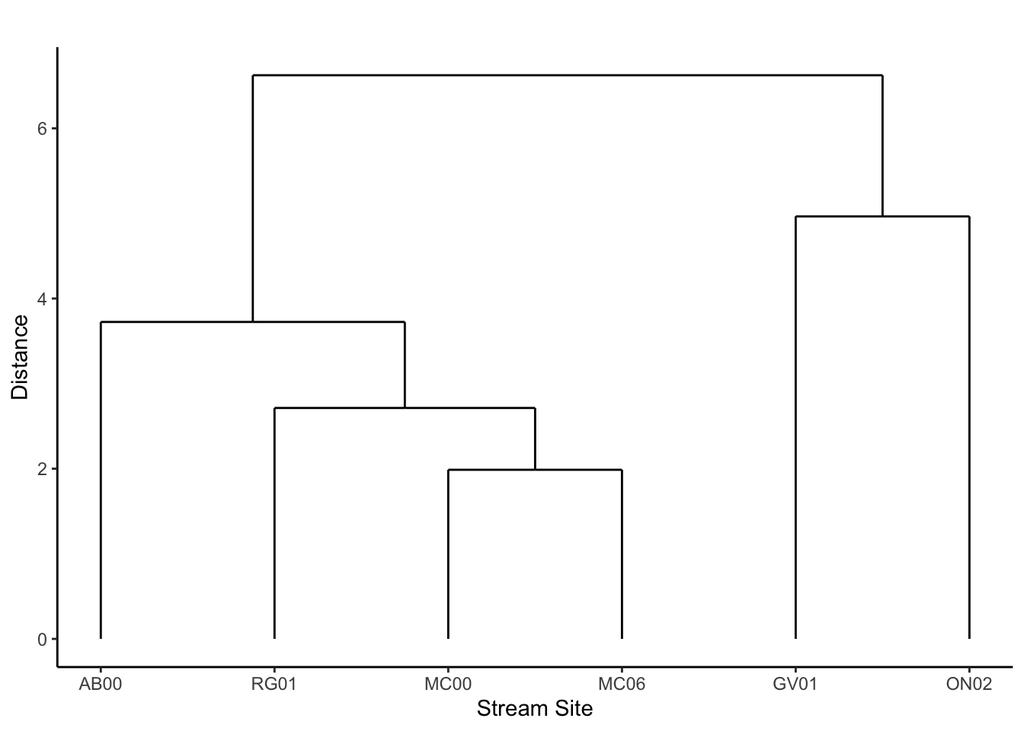

```r
#Create dendrogram
ggdendrogram(clust_complete) +
  theme_classic() +
  labs(x = "Stream Site", y = "Distance",
       title = "")
```

**Figure 1.** Illustrates relationships between six sites at the the Santa Barbara Coastal Long Term Ecological Research (LTER). Dendrogram was crafted utilizing complete linkage agglomerative hierarchical clustering and Euclidian distance measurements to illucidate proximity among sites based on environmental variables.